# Class 7 Lecture Demo

Spring 2022

## Class 7 Lecture Demo: Spatial Analysis & Geoprocessing

- [Class 6 Map Submissions](https://weekly-submissions.s3.amazonaws.com/c6_sp22_submissions.pdf)
- [Lecture 7 Agenda](https://gis-nspe-tns.github.io/GIS_NINT5380_spring_2022/agendas/c7_agenda_spring_22_NINT5380.html)
- [Link to Lecture 7](https://gis-nspe-tns.github.io/GIS_NINT5380_spring_2022/lectures/lecture.7/index.html)
- [Lecture 7 Demo Data](https://drive.google.com/file/d/1x1AC6Evkxp4uqSoqOvRm5tSFLdEdBkua/view?usp=sharing)

> Note: mapPLUTO data and its `ESPG 102718` and `FIPS3104` codes - these are short-cut notations for projections. If you want to explore the original data for the lab - mapPLUTO - make sure to unzip the data for mapPLUTO and use `ESPG 102718` and `FIPS3104` to find the correct projection:

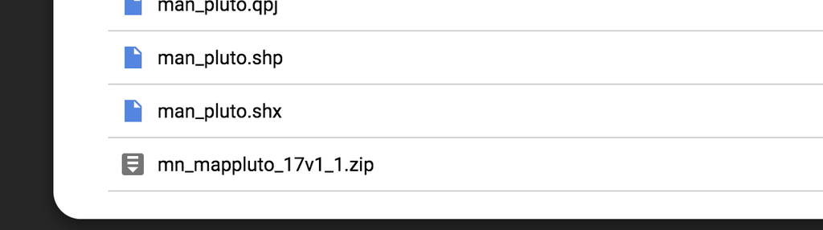

> *Lecture 7 Demo Data*

## Core Vector Geoprocessing Tools:

- Buffer - one layer

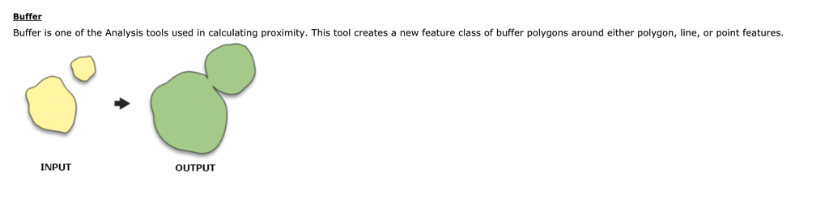

*Buffer Tool*

- Dissolve - 1 layer:

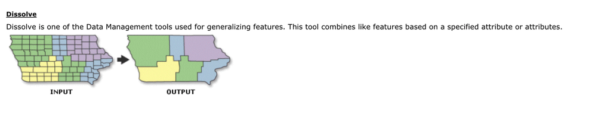

*Feature Dissolve*

- Clip 2 layers:

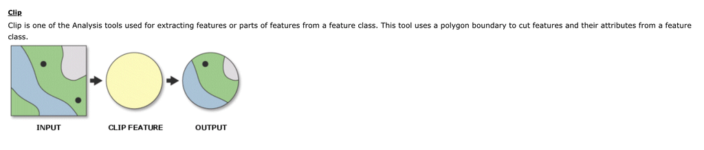

*Clipping Tool*

- Intersect - 2 layers:

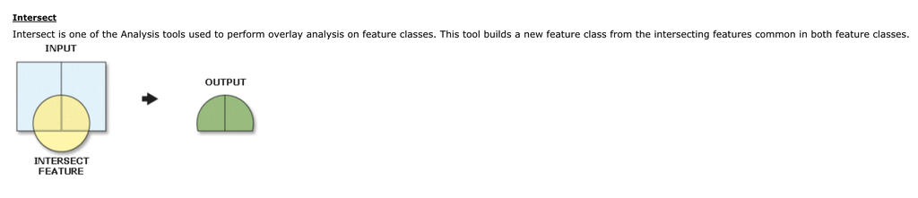

*Spatial Intersections*

- Union - 2 layers:

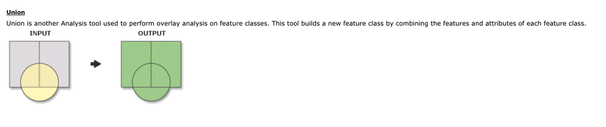

*Union Tool*

- Erase - 2 layers:

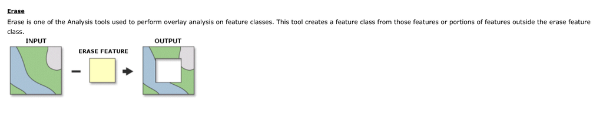

*Erase Tool*

### Demo Steps:

- **To start**, we will download data needed for the lab from [Demo Data](https://drive.google.com/file/d/1x1AC6Evkxp4uqSoqOvRm5tSFLdEdBkua/view?usp=sharing). Following the download, we will unzip the data and point our GIS to the data and secure a file path for the duration of the lab. Data download includes:
  - `ManPLUTO.shp`
  - `man_centroid.shp`
  - `man_build.shp`
- Inside the working folder, create a new folder called `exports` that will hold export `.shps` developed during this lab.
- **Step 1 - Geoprocessing - Buffer (1 mile Central Park Centroid)**:
  - IMPORT `man_centroid.shp` to TOC (table of contents)
  - BUFFER `man_centroid.shp` - 1 mile distance buffer. Name output `cen_buff.shp`
  - EXPORT `cen_buff.shp` to scratch folder (`exports`)
- **Step 2 - Geoprocessing - Clip #1 (Pluto Parcels)**:
  - IMPORT `ManPLUTO.shp`
  - CLIP `ManPLUTO.shp` - Clip layer = `cen_buff.shp`. Name output `manPLUTO_clip.shp`
  - EXPORT `manPLUTO_clip.shp` to scratch folder (`exports`)
- **Step 3 - Geoprocessing - Clip #2 (NYC Buildings Footprint)**:
  - IMPORT `man_build.shp`
  - CLIP `man_build.shp` - Clip layer = `cen_buff.shp`. Name output `manbuild_clip.shp`
  - EXPORT `manbuild_clip.shp` to scratch folder (`exports`)
- **Step 4 - Geoprocessing - Union (Buildings Footprint + Pluto)**:
  - UNION `manbuild_clip.shp` + `manPLUTO_clip.shp`. Name output `man_union.shp`
  - EXPORT `man_union.shp` to scratch folder (`exports`)
  - Visually REVIEW attribute table of `man_union.shp`
- **Step 5 - Geoprocessing - Intersect (Buildings Footprint + Pluto)**:
  - INTERSECT `manbuild_clip.shp` + `manPLUTO_clip.shp`. Name output `man_intersect.shp`
  - EXPORT `man_intersect.shp` to scratch folder (`exports`)
  - Visually REVIEW attribute table of `man_intersect.shp`
- **Step 6 - Geoprocessing - DISSOLVE (Intersect results from step 5)**:
  - DISSOLVE `man_intersect.shp`. Name output `man_dissolve.shp`
  - EXPORT `man_dissolve.shp` to scratch folder (`exports`)
  - Visually REVIEW attribute table of `man_dissolve.shp`
- **Step 7 - Calculate Feature Geometry (Pluto Parcels)**:
  - ADD FIELD TO `manPLUTO_clip.shp`, Column Type = **FLOAT**; Name = **A_METER**
  - CALCULATE GEOMETRY Tool within new **A_METER** column; Units = Sq. Meter
- **Step 8 - Assign Values | Weights (Pluto Parcels)**:
  - ADD FIELD TO `manPLUTO_clip.shp`, Column Type = **Text**; Name = **A_VALUE**
  - ASSIGN qualitative values in **A_VALUE** for area quantities in **A_METER**
    - SQL Following within **A_METER**:
    - `A_METER<=200` - Assign value `small` within **A_Value**
    - `A_METER>=200 and A_METER<=3000` - assign `medium` in **A_VALUE**
    - `A_METER>=3000` - Assign value `Large` within **A_Value**
- **Step 9 - Thematically Map | Parcel Sizes S/M/L (Pluto Parcels)**:
  - THEMATICALLY MAP **A_VALUE** via categories, unique values (Qualitative)

#### Further Reference:

Utilize the [image below as visual cue](https://i.imgur.com/6E4IR67.png) for fundamental geoprocessing tasks:

- Clip
- Dissolve
- Intersect
- Merge
- Union

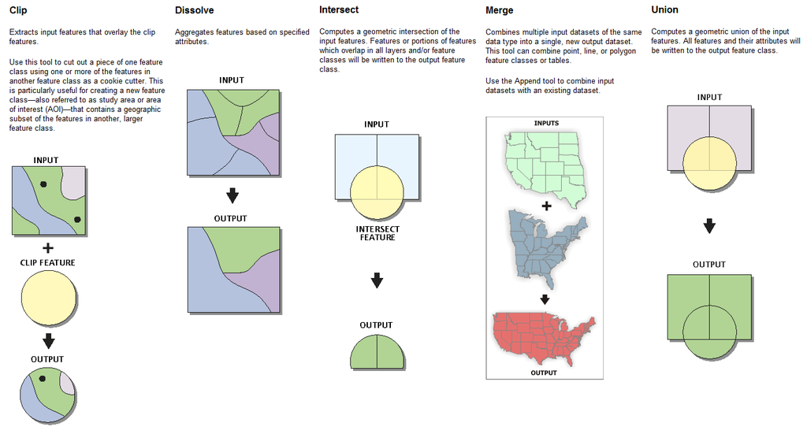

*Vector Geoprocessing Tools*